# Practical Machine Learning Coursera Project 1

## Data Collection:

This is a Coursera peer assignment in which the training and test data for the project was collected from the links below:

Training Data: https://d396qusza40orc.cloudfront.net/predmachlearn/pml-training.csv

Test Data: https://d396qusza40orc.cloudfront.net/predmachlearn/pml-testing.csv

## Loading and Processing Data

I order to establish what features to select a data cleaning exercise was first performed. The result of the exercise was: - A data frame containing 19622 observations and 54 variables of the training data. - A data frame containing 20 observations and 54 variables of the testing data The above was achieved by removing all factor variables and non-numeric variables from the datasets.

Having a large data set possibility of highly correlated variable exist. In order to establish this a correlation matrix used. A matrix of Pearson-type correlations was created for the data and highly correlated attributes where identified.

The highly correlated attributes with an absolute correlation of 0.5 or higher where removed from the dataset.

The result was a reduced dataset containing 22 features

```r
# Load library
library(mlbench)
library(caret)
# Get the data
training = read.csv("C:/Users/zambezis/Desktop/Data Science Coursera/Practical Machine Learning/pml-training.csv")
testing = read.csv("C:/Users/zambezis/Desktop/Data Science Coursera/Practical Machine Learning/pml-testing.csv")
# Remove all non-numeric and non-integer variables

data_1 <- training[,7:160]
data_2<- data_1[,-c(grep("kurtosis", colnames(data_1)))]
data_3<- data_2[,-c(grep("skewness", colnames(data_2)))]
data_4 <- data_3[,-c(grep("max", colnames(data_3)))]
data_5 <- data_4[,-c(grep("min", colnames(data_4)))]
data_6 <- data_5[,-c(grep("amplitude", colnames(data_5)))]
data_7 <- data_6[,-c(grep("var", colnames(data_6)))]
data_8 <- data_7[,-c(grep("avg", colnames(data_7)))]
data_f <- data_8[,-c(grep("stddev", colnames(data_8)))]

data_1T <- testing[,7:160]
data_2T<- data_1T[,-c(grep("kurtosis", colnames(data_1T)))]
data_3T<- data_2T[,-c(grep("skewness", colnames(data_2T)))]
data_4T <- data_3T[,-c(grep("max", colnames(data_3T)))]
data_5T <- data_4T[,-c(grep("min", colnames(data_4T)))]
data_6T <- data_5T[,-c(grep("amplitude", colnames(data_5T)))]
data_7T <- data_6T[,-c(grep("var", colnames(data_6T)))]
data_8T <- data_7T[,-c(grep("avg", colnames(data_7T)))]
data_fT <- data_8T[,-c(grep("stddev", colnames(data_8T)))]

#processing for correlation
correlationMatric <- cor(data_f[,1:53])
highlyCorrelated <- findCorrelation(correlationMatric, cutoff = 0.5)
highlyCorrelated <- sort(highlyCorrelated)
# remove highly correlated data
reduced_data <- data_f[,-c(highlyCorrelated)]
# data reduced to 22 variables/features
# Apply same reduction method to testing data
reduced_data2 <- data_fT[,-c(highlyCorrelated)]
```

## Split data to a validation set

The training data was split to obtain a new training and validation set

```r
# create new training and validation set
set.seed(3333)
inTrain <- createDataPartition(y = reduced_data$classe, p = 0.7, list = FALSE)
train <- reduced_data[inTrain,]
validation.data <- reduced_data[-inTrain,]
```

## Random Forest Model and Feature Selection

```r
modelfit <- train(classe ~ ., method = "rf", data = train, importance = T, trControl = trainControl(method = "cv", number = 5))
```

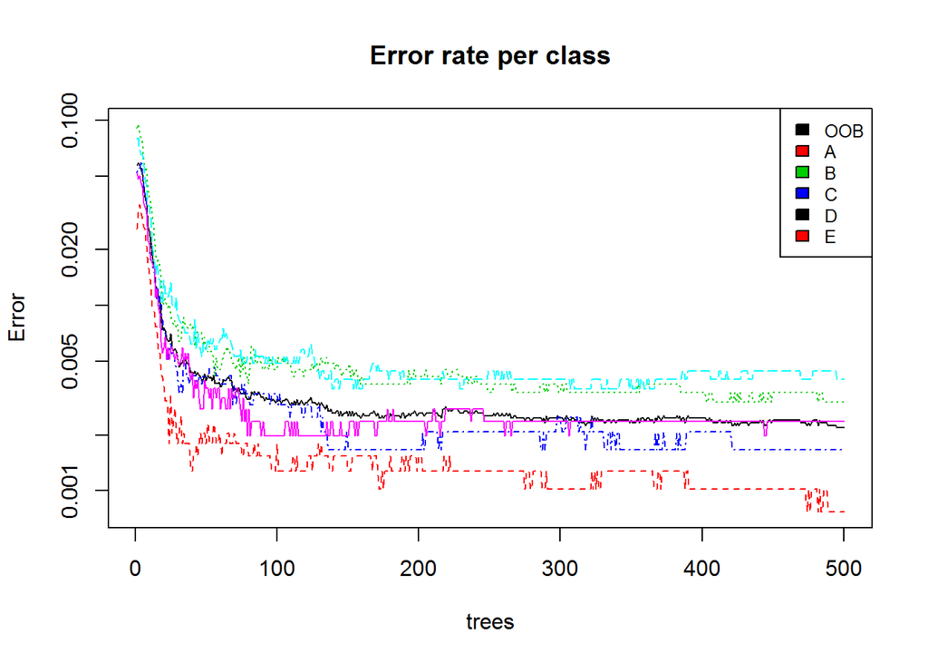

```r
df <- modelfit$finalModel
#plot error rate per class
plot(df, log ="y", main =  "Error rate per class")
legend("topright", colnames(df$err.rate),col=1:4,cex=0.8,fill=1:4)
```

```r
#obtain confusion matrix
df$confusion
```

```
##      A    B    C    D    E  class.error
## A 3903    3    0    0    0 0.0007680492
## B    5 2650    2    1    0 0.0030097818
## C    0    2 2392    2    0 0.0016694491
## D    0    0    8 2243    1 0.0039964476
## E    0    1    0    5 2519 0.0023762376
```

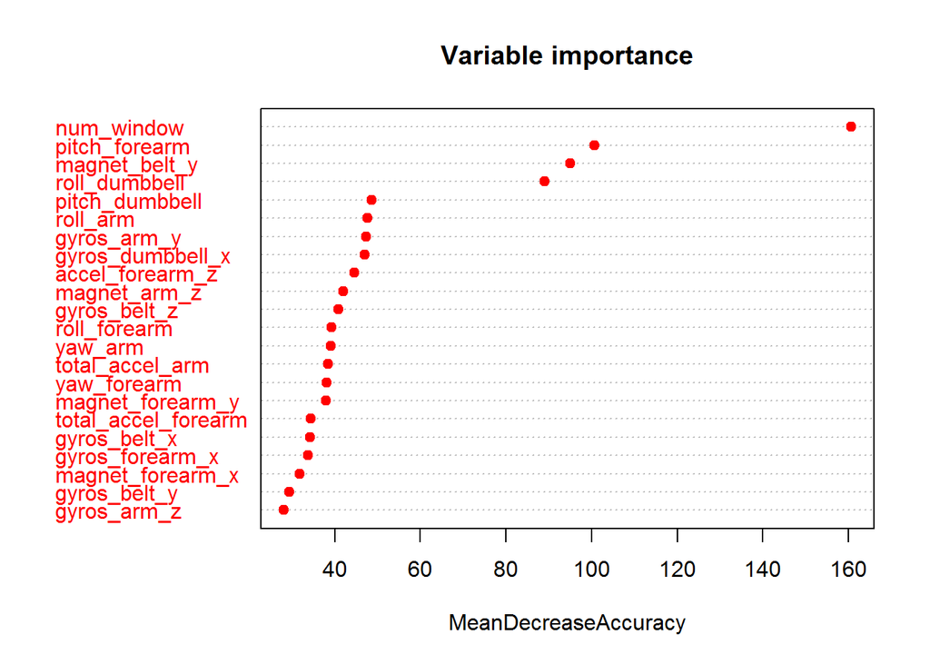

```r
#variable importance
var_importance <- varImp(modelfit)$importance
varImpPlot(df, sort = TRUE, type = 1, pch = 19, col = 2, main = "Variable importance")
```

## Estimation of test error

Futher estimation of test error was obtained by fitting the model on the validation set

```r
pred_1 <- predict(modelfit, newdata = validation.data)
# get test estimate
confusionMatrix(pred_1, validation.data$classe)
```

```
## Confusion Matrix and Statistics
##
##           Reference
## Prediction    A    B    C    D    E
##          A 1669    0    0    0    0
##          B    5 1137    0    3    1
##          C    0    1 1024    0    0
##          D    0    0    2  960    1
##          E    0    1    0    1 1080
##
## Overall Statistics
##
##                Accuracy : 0.9975
##                  95% CI : (0.9958, 0.9986)
##     No Information Rate : 0.2845
##     P-Value [Acc > NIR] : < 2.2e-16
##
##                   Kappa : 0.9968
##  Mcnemar's Test P-Value : NA
##
## Statistics by Class:
##
##                      Class: A Class: B Class: C Class: D Class: E
## Sensitivity            0.9970   0.9982   0.9981   0.9959   0.9982
## Specificity            1.0000   0.9981   0.9998   0.9994   0.9996
## Pos Pred Value         1.0000   0.9921   0.9990   0.9969   0.9982
## Neg Pred Value         0.9988   0.9996   0.9996   0.9992   0.9996
## Prevalence             0.2845   0.1935   0.1743   0.1638   0.1839
## Detection Rate         0.2836   0.1932   0.1740   0.1631   0.1835
## Detection Prevalence   0.2836   0.1947   0.1742   0.1636   0.1839
## Balanced Accuracy      0.9985   0.9982   0.9989   0.9976   0.9989
```

## Prediction

The random forest model was used to predict on the testing set.

```r
# predict on testing set
pred_2 <- predict(modelfit, newdata = reduced_data2)
pred_2 <- as.data.frame(pred_2)
#save predicted values
df_3 <- cbind(testing, pred_2$pred_2)
colnames(df_3)[161] = "problem_id"
df_4 <- df_3[-160]
write.csv(df_4, file = "predicted.csv")
```